# Prosper Loan Data Exploration

## Preliminary Wrangling

> Prosper Loan data provided by Udacity. Prosper.com is a peer-to-peer lending marketplace. Borrowers make loan requests and investors contribute towards the loans of their choice.

```python
# import all packages and set plots to be embedded inline
import numpy as np
import pandas as pd
import matplotlib.pyplot as plt
import seaborn as sns

%matplotlib inline
```

```python
# Load the dataset
df_orig = pd.read_csv('../prosperLoanData.csv')
df_orig.head()
```

|  | ListingKey | ListingNumber | ListingCreationDate | CreditGrade | Term | LoanStatus | ClosedDate | BorrowerAPR | BorrowerRate | LenderYield | ... | LP_ServiceFees | LP_CollectionFees | LP_GrossPrincipalLoss | LP_NetPrincipalLoss | LP_NonPrincipalRecoverypayments | PercentFunded | Recommendations | InvestmentFromFriendsCount | InvestmentFromFriendsAmount | Investors |
| --- | --- | --- | --- | --- | --- | --- | --- | --- | --- | --- | --- | --- | --- | --- | --- | --- | --- | --- | --- | --- | --- |
| 0 | 1021339766868145413AB3B | 193129 | 2007-08-26 19:09:29.263000000 | C | 36 | Completed | 2009-08-14 00:00:00 | 0.16516 | 0.1580 | 0.1380 | ... | -133.18 | 0.0 | 0.0 | 0.0 | 0.0 | 1.0 | 0 | 0 | 0.0 | 258 |
| 1 | 10273602499503308B223C1 | 1209647 | 2014-02-27 08:28:07.900000000 | NaN | 36 | Current | NaN | 0.12016 | 0.0920 | 0.0820 | ... | 0.00 | 0.0 | 0.0 | 0.0 | 0.0 | 1.0 | 0 | 0 | 0.0 | 1 |
| 2 | 0EE9337825851032864889A | 81716 | 2007-01-05 15:00:47.090000000 | HR | 36 | Completed | 2009-12-17 00:00:00 | 0.28269 | 0.2750 | 0.2400 | ... | -24.20 | 0.0 | 0.0 | 0.0 | 0.0 | 1.0 | 0 | 0 | 0.0 | 41 |
| 3 | 0EF5356002482715299901A | 658116 | 2012-10-22 11:02:35.010000000 | NaN | 36 | Current | NaN | 0.12528 | 0.0974 | 0.0874 | ... | -108.01 | 0.0 | 0.0 | 0.0 | 0.0 | 1.0 | 0 | 0 | 0.0 | 158 |
| 4 | 0F023589499656230C5E3E2 | 909464 | 2013-09-14 18:38:39.097000000 | NaN | 36 | Current | NaN | 0.24614 | 0.2085 | 0.1985 | ... | -60.27 | 0.0 | 0.0 | 0.0 | 0.0 | 1.0 | 0 | 0 | 0.0 | 20 |

5 rows × 81 columns

```python
print(df_orig.shape)
print(df_orig.info())
```

```
(113937, 81)
<class 'pandas.core.frame.DataFrame'>
RangeIndex: 113937 entries, 0 to 113936
Data columns (total 81 columns):
ListingKey                             113937 non-null object
ListingNumber                          113937 non-null int64
ListingCreationDate                    113937 non-null object
CreditGrade                            28953 non-null object
Term                                   113937 non-null int64
LoanStatus                             113937 non-null object
ClosedDate                             55089 non-null object
BorrowerAPR                            113912 non-null float64
BorrowerRate                           113937 non-null float64
LenderYield                            113937 non-null float64
EstimatedEffectiveYield                84853 non-null float64
EstimatedLoss                          84853 non-null float64
EstimatedReturn                        84853 non-null float64
ProsperRating (numeric)                84853 non-null float64
ProsperRating (Alpha)                  84853 non-null object
ProsperScore                           84853 non-null float64
ListingCategory (numeric)              113937 non-null int64
BorrowerState                          108422 non-null object
Occupation                             110349 non-null object
EmploymentStatus                       111682 non-null object
EmploymentStatusDuration               106312 non-null float64
IsBorrowerHomeowner                    113937 non-null bool
CurrentlyInGroup                       113937 non-null bool
GroupKey                               13341 non-null object
DateCreditPulled                       113937 non-null object
CreditScoreRangeLower                  113346 non-null float64
CreditScoreRangeUpper                  113346 non-null float64
FirstRecordedCreditLine                113240 non-null object
CurrentCreditLines                     106333 non-null float64
OpenCreditLines                        106333 non-null float64
TotalCreditLinespast7years             113240 non-null float64
OpenRevolvingAccounts                  113937 non-null int64
OpenRevolvingMonthlyPayment            113937 non-null float64
InquiriesLast6Months                   113240 non-null float64
TotalInquiries                         112778 non-null float64
CurrentDelinquencies                   113240 non-null float64
```

[output cut: 33 more lines]

```
LP_CustomerPrincipalPayments           113937 non-null float64
LP_InterestandFees                     113937 non-null float64
LP_ServiceFees                         113937 non-null float64
LP_CollectionFees                      113937 non-null float64
LP_GrossPrincipalLoss                  113937 non-null float64
LP_NetPrincipalLoss                    113937 non-null float64
LP_NonPrincipalRecoverypayments        113937 non-null float64
PercentFunded                          113937 non-null float64
Recommendations                        113937 non-null int64
InvestmentFromFriendsCount             113937 non-null int64
InvestmentFromFriendsAmount            113937 non-null float64
Investors                              113937 non-null int64
dtypes: bool(3), float64(50), int64(11), object(17)
memory usage: 68.1+ MB
None
```

```python
print(df_orig['ListingCreationDate'].head(3))
print(df_orig['ListingCreationDate'].tail(3))
```

```
0    2007-08-26 19:09:29.263000000
1    2014-02-27 08:28:07.900000000
2    2007-01-05 15:00:47.090000000
Name: ListingCreationDate, dtype: object
113934    2013-12-13 05:49:12.703000000
113935    2011-11-14 13:18:26.597000000
113936    2014-01-15 09:27:37.657000000
Name: ListingCreationDate, dtype: object
```

```python
df = df_orig.copy()
```

```python
# Subset the dataframe by selecting features of interest
cols = ['ListingCreationDate', 'LoanOriginalAmount', 'BorrowerAPR', 'StatedMonthlyIncome', 'Term', 'ProsperRating (Alpha)',
        'DebtToIncomeRatio', 'EmploymentStatus', 'ListingCategory (numeric)']
df_sub = df[cols].copy()
```

```python
# Check if the loan data is continuos
df_sub['ListingCreationDate'] = pd.to_datetime(df_sub['ListingCreationDate'], format='%Y-%m-%d %H:%M:%S')
df_sub = df_sub.sort_values(by='ListingCreationDate',ascending=True)
```

```python
print(df_sub['ListingCreationDate'].head(3))
print(df_sub['ListingCreationDate'].tail(3))
```

```
113921   2005-11-09 20:44:28.847
106735   2005-11-11 08:46:17.303
25166    2005-11-15 16:06:47.457
Name: ListingCreationDate, dtype: datetime64[ns]
67741   2014-03-10 10:25:51.877
32376   2014-03-10 11:28:06.920
14131   2014-03-10 12:20:53.760
Name: ListingCreationDate, dtype: datetime64[ns]
```

```python
df_sub.isnull().sum()
```

```
ListingCreationDate              0
LoanOriginalAmount               0
BorrowerAPR                     25
StatedMonthlyIncome              0
Term                             0
ProsperRating (Alpha)        29084
DebtToIncomeRatio             8554
EmploymentStatus              2255
ListingCategory (numeric)        0
dtype: int64
```

We can see that many variables which are of interest to us have missing values which needs to be addressed.

APR is an important value, however, 25 missing BorrowerAPR values in the dataset. An easy fix is to caculate the missing APR as we know that **BorrowerAPR = BorrowerRate + fee, where fee = BorrowerAPR - BorrowerRate**. So we can caculate the median fee, then add them to the missing records.

```python
borrower_fees = df["BorrowerAPR"] - df["BorrowerRate"]
borrower_fees.median()
```

```
0.025019999999999987
```

```python
df_sub["BorrowerAPR"].fillna(df["BorrowerRate"] + borrower_fees.median(), inplace=True)
# Check to make sure the cells are filled
df_sub["BorrowerAPR"].isnull().sum()
```

```
0
```

```python
df_sub["DebtToIncomeRatio"].fillna(0.0, inplace = True)
df_sub["DebtToIncomeRatio"].isnull().sum()
```

```
0
```

Also, the other variables `ProsperRating (Alpha)` and `EmploymentStatus` can't be replaced with other values and dropping those records will result in loss of information. Hence, I am just leaving them as Null.

```python
df_sub.isnull().sum()
```

```
ListingCreationDate              0
LoanOriginalAmount               0
BorrowerAPR                      0
StatedMonthlyIncome              0
Term                             0
ProsperRating (Alpha)        29084
DebtToIncomeRatio                0
EmploymentStatus              2255
ListingCategory (numeric)        0
dtype: int64
```

### What is the structure of your dataset?

- This data set contains 113,937 loans with 81 variables on each loan, including loan amount, borrower rate (or interest rate), current loan status, borrower income, and many others.

### What is/are the main feature(s) of interest in your dataset?

- I am most interested in finding out which features are best for predicting the borrower's Annual Percentage Rate (APR) for the loan. Also, I am interested in finding out the trends of the number of loans generated over the years as well as the income range of the borrowers of those loans.

### What features in the dataset do you think will help support your investigation into your feature(s) of interest?

- I think that the total loan amount will influence the APR of the loan. Also the borrowers stated monthly income, listing category, loan term, Prosper rating, DebtToIncomeRatio and Employment status will also have effects on the APR.
- Also a better idea about the assets of the borrower would make it clear how the loans are rated.

## Univariate Exploration

First I am interested in exploring the overall trend of the number of loans issued to borrowers by prosper loans over the years.

```python
num_of_records = df_sub['ListingCreationDate'].groupby(df_sub.ListingCreationDate.dt.to_period("M")).agg('count')
```

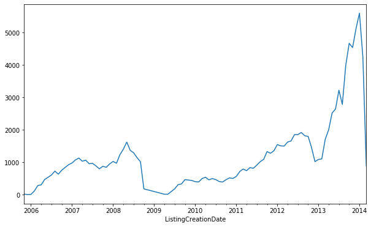

```python
num_of_records.plot(figsize=(10,6));
```

The number of loans with time is showing an increasing trend. We can also see that there are two steep drops in the number of loans borrowed, one between the year 2008 to 2009 which was the period of The Great Depression and the other at the end of 2012 which lasted for a shorter period of time. Also after further research it was known that the SEC imposed a cease and desist order on Prosper from the end of November 2008 till July 2009, which explains the steep fall in the number of loans issued.

Let's dwelve into our main features of interest and start by looking at the distribution of Borrower APR.

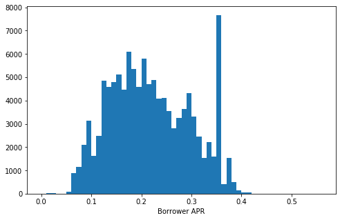

```python
bins = np.arange(0, df_sub.BorrowerAPR.max()+0.05, 0.01)
plt.figure(figsize=[8, 5])
plt.hist(data = df_sub, x = 'BorrowerAPR', bins = bins);
plt.xlabel('Borrower APR');
```

The distribution of Borrower APR looks slightly multimodal. A small peak centered at 0.1, a large peak centered at 0.2. There is also a small peak centered 0.3. Additionally, there is a very sharpe peak between 0.35 and 0.36.Very few loans have Borrower APR greater than 0.43

```python
# Check loans with APR greater than 0.43
df_sub[df_sub.BorrowerAPR>0.43]
```

|  | ListingCreationDate | LoanOriginalAmount | BorrowerAPR | StatedMonthlyIncome | Term | ProsperRating (Alpha) | DebtToIncomeRatio | EmploymentStatus | ListingCategory (numeric) |
| --- | --- | --- | --- | --- | --- | --- | --- | --- | --- |
| 36018 | 2006-02-23 13:57:02.087 | 1500 | 0.51229 | 2838.000000 | 36 | NaN | 0.02852 | NaN | 0 |
| 82043 | 2006-03-02 19:00:17.593 | 3000 | 0.48873 | 1583.333333 | 36 | NaN | 0.10021 | NaN | 0 |
| 103973 | 2006-03-06 22:36:53.753 | 2800 | 0.45857 | 3750.000000 | 36 | NaN | 0.19413 | NaN | 0 |
| 18326 | 2006-03-11 15:43:45.393 | 3000 | 0.45857 | 10000.000000 | 36 | NaN | 0.10252 | NaN | 0 |
| 22195 | 2006-03-12 13:44:15.060 | 1789 | 0.46201 | 2916.666667 | 36 | NaN | 0.35430 | NaN | 0 |
| 56761 | 2006-03-16 19:30:16.753 | 3000 | 0.50633 | 0.000000 | 36 | NaN | 0.03909 | NaN | 0 |

The borrowers with largest APR have small loan amount and don't have records of Prosper rating and employment status.

Now lets explore the category of listing that borrowers selected the most when posting their listing, `ListingCategory`.

```python
df_sub['ListingCategory (numeric)'].value_counts()
```

```
1     58308
0     16965
7     10494
2      7433
3      7189
6      2572
4      2395
13     1996
15     1522
18      885
14      876
20      771
19      768
5       756
16      304
11      217
8       199
10       91
9        85
12       59
17       52
Name: ListingCategory (numeric), dtype: int64
```

The category of the listing that the borrower selected when posting their listing: 0 - Not Available, 1 - Debt Consolidation, 2 - Home Improvement, 3 - Business, 4 - Personal Loan, 5 - Student Use, 6 - Auto, 7- Other, 8 - Baby&Adoption, 9 - Boat, 10 - Cosmetic Procedure, 11 - Engagement Ring, 12 - Green Loans, 13 - Household Expenses, 14 - Large Purchases, 15 - Medical/Dental, 16 - Motorcycle, 17 - RV, 18 - Taxes, 19 - Vacation, 20 - Wedding Loans

```python
df_sub['ListingCategory'] = df_sub['ListingCategory (numeric)'].map(
    {0:'NA', 1:'Debt Consolidation', 2:'Home Improvement', 3:'Business',
     4:'Personal Loan', 5:'Student Use', 6:'Auto', 7:'Other', 8:'Baby&Adoption',
     9:'Boat', 10:'Cosmetic Procedure', 11:'Engagement Ring', 12:'Green Loans', 13:'Household Expenses',
     14:'Large Purchases', 15:'Medical/Dental', 16:'Motorcycle', 17:'RV', 18:'Taxes', 19:'Vacation', 20:'Wedding Loans'})
# df['gender'] = df['gender'].map({1:'male', 2:'female'})
```

```python
df_sub.info()
```

```
<class 'pandas.core.frame.DataFrame'>
Int64Index: 113937 entries, 113921 to 14131
Data columns (total 10 columns):
ListingCreationDate          113937 non-null datetime64[ns]
LoanOriginalAmount           113937 non-null int64
BorrowerAPR                  113937 non-null float64
StatedMonthlyIncome          113937 non-null float64
Term                         113937 non-null int64
ProsperRating (Alpha)        84853 non-null object
DebtToIncomeRatio            113937 non-null float64
EmploymentStatus             111682 non-null object
ListingCategory (numeric)    113937 non-null int64
ListingCategory              113937 non-null object
dtypes: datetime64[ns](1), float64(3), int64(3), object(3)
memory usage: 14.6+ MB
```

```python
df_sub['ListingCategory'] = df_sub['ListingCategory'].astype('category')
```

```python
sorted_category = df_sub['ListingCategory'].value_counts().index
```

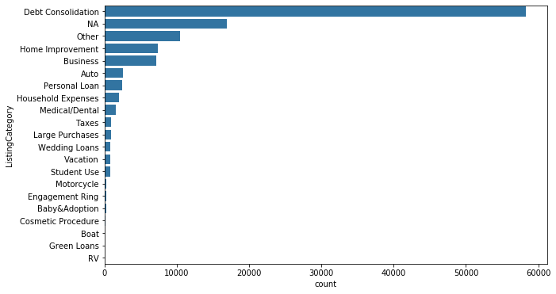

```python
plt.figure(figsize = [10, 6])
base_color = sns.color_palette()[0]
sns.countplot(y="ListingCategory", data=df_sub, color = base_color, order=sorted_category);
# plt.xticks(rotation = 60)
```

**Debt Consolidation** is the category of listing that borrowers selected the most when posting their listing, whereas **Cosmetic Procedure, Boat, Green Loans and RV** are the least selected categories.

Now let's look at the distribution of `LoanOriginalAmount`

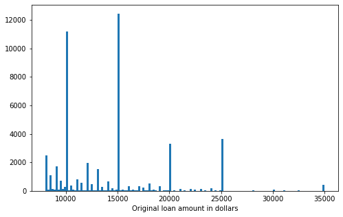

```python
bins = np.arange(8000, df_sub.LoanOriginalAmount.max()+200, 200)
plt.figure(figsize=[8, 5])
plt.hist(data = df_sub, x = 'LoanOriginalAmount', bins = bins);
plt.xlabel('Original loan amount in dollars');
```

Lets look at the distributions of other variables of interest, `StatedMontlyIncome`

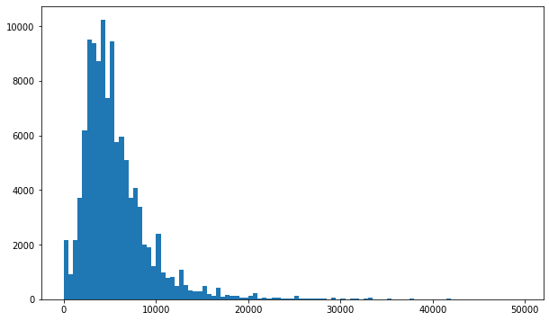

```python
# Distribution of stated monthly income
bins_smi = np.arange(0, 50000, 500)
plt.figure(figsize=[10, 6])
plt.hist(data = df_sub, x = 'StatedMonthlyIncome', bins=bins_smi);
```

The distribution of stated monthly income is severely right skewed, with most of stated monthly income less than 30k.

Let's check what percentage of borrowers have stated their monthly income to be greater than 30k

```python
# Get percent of borrowers whose stated monthly income greater than 30k
(df_sub.StatedMonthlyIncome>30000).sum()/float(df_sub.shape[0])
```

```
0.002870007109191922
```

Less than 0.3 percent borrowers have stated monthly income greater than 30k. These can be considered as outliers for our analysis, so it is better to remove borrower records with income greater than 30k.

```python
# remove loans with stated monthly income greater than 30k, which are outliers
df_sub = df_sub[df_sub.StatedMonthlyIncome<=30000]
```

```python
(df_sub.StatedMonthlyIncome>30000).sum()
```

```
0
```

What distribution does `DebtToIncomeRatio` of each borrower has?

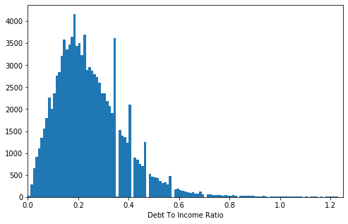

```python
binsize = 0.01
bins = np.arange(0.2, 1.25, 0.01)
bins = np.arange(0, df_sub['DebtToIncomeRatio'].max()+binsize, binsize)

plt.figure(figsize=[8, 5])
plt.hist(data = df_orig, x = 'DebtToIncomeRatio', bins = bins)
plt.xlim([0,1.25])
plt.xlabel('Debt To Income Ratio')
plt.show()
```

It is observed that `DebtToIncomeRatio` is also right skewed and has unusual spikes near 0.35, 0.42, 0.45 with the highest being at 0.2 which seems to be the most `DebtToIncomeRatio` for most of the borrowers.

Finally lets check the distributions of terms `Prosper rating` and `Employment status`

```python
# Convert Term, ProsperRating and Employment status into ordered categorical types
rating_order = ['HR','E','D','C','B','A','AA']
ordered_var = pd.api.types.CategoricalDtype(ordered = True,
                                    categories = rating_order)
df_sub['ProsperRating (Alpha)'] = df_sub['ProsperRating (Alpha)'].astype(ordered_var)

emp_order = ['Employed','Self-employed','Full-time','Part-time','Retired','Other','Not employed', 'Not available']
ordered_var = pd.api.types.CategoricalDtype(ordered = True,
                                    categories = emp_order)
df_sub['EmploymentStatus'] = df_sub['EmploymentStatus'].astype(ordered_var)

term_order = [12, 36, 60]
ordered_var = pd.api.types.CategoricalDtype(ordered = True, categories = term_order)
df_sub['Term'] = df_sub['Term'].astype(ordered_var)
```

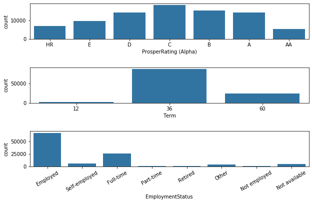

```python
fig, ax = plt.subplots(nrows=3, figsize = [10,6])
base_color = sns.color_palette()[0]
sns.countplot(data = df_sub, x = 'ProsperRating (Alpha)', color = base_color, ax = ax[0])
sns.countplot(data = df_sub, x = 'Term', color = base_color, ax = ax[1])
sns.countplot(data = df_sub, x = 'EmploymentStatus', color = base_color, ax = ax[2])
plt.xticks(rotation=30)
plt.subplots_adjust(hspace = 0.8)
plt.show()
```

The ratings of most of the borrowers is C with a considerable amount of borrowers having ratings A, B and D. Most of borrowers are employed and Full-time.

### Discuss the distribution(s) of your variable(s) of interest. Were there any unusual points? Did you need to perform any transformations?

- The distribution of borrowers APR looks slightly multimodal. Most of the values are at the range of 0.05 and 0.4.
- The distribution of stated monthly income is severely right skewed, with most of stated monthly income less than 30k.
- There are many 'Not Available' values in the category of listing that borrowers selected.
- The Debt to Income Ratio is right skewed and has many high spikes at many values.

### Of the features you investigated, were there any unusual distributions? Did you perform any operations on the data to tidy, adjust, or change the form of the data? If so, why did you do this?

No other unlikely/unusual distributions were noticed and hence any other transformations were not performed.

## Bivariate Exploration

For starters, let's look at the pairwise correlations present between features of interest in the data.

```python
num_vars = ['LoanOriginalAmount', 'BorrowerAPR', 'StatedMonthlyIncome', 'DebtToIncomeRatio']
cat_vars = ['Term', 'ProsperRating (Alpha)', 'EmploymentStatus']
```

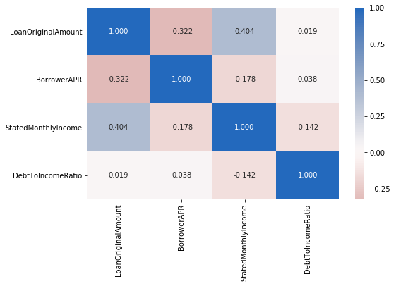

```python
# correlation plot
plt.figure(figsize = [8, 5])
sns.heatmap(df_sub[num_vars].corr(), annot = True, fmt = '.3f',
           cmap = 'vlag_r', center = 0);
```

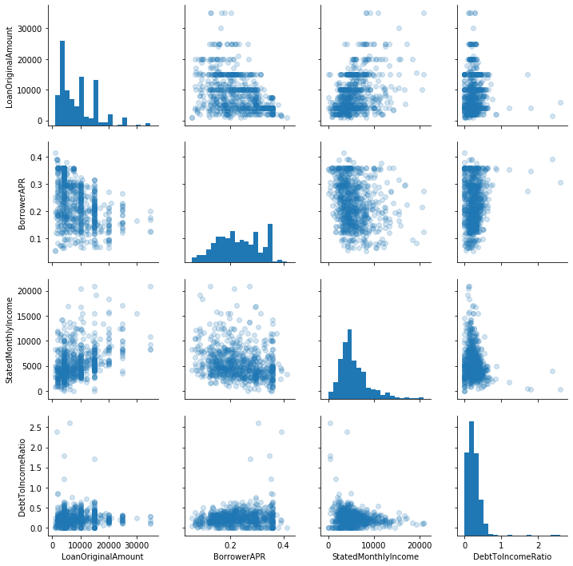

```python
# plot matrix: lets sample 1000 loans so that plots are clearer and render faster
df_sub_samp = df_sub.sample(1000)
g = sns.PairGrid(data = df_sub_samp.dropna(), vars = num_vars)
g = g.map_diag(plt.hist, bins=20)
g.map_offdiag(plt.scatter, alpha=0.2);
```

Now let's look at relationships between the three categorical features.

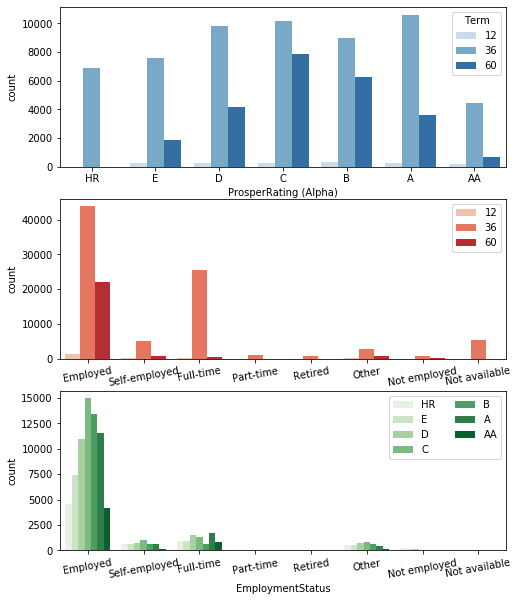

```python
plt.figure(figsize = [8, 10])

# subplot 1: Prosper rating vs term
plt.subplot(3, 1, 1)
sns.countplot(data = df_sub, x = 'ProsperRating (Alpha)', hue = 'Term', palette = 'Blues')

# subplot 2: employment status vs. term
ax = plt.subplot(3, 1, 2)
sns.countplot(data = df_sub, x = 'EmploymentStatus', hue = 'Term', palette = 'Reds')
ax.legend(loc = 1);
plt.xticks(rotation=10)

# subplot 3: Prosper rating vs. employment status, use different color palette
ax = plt.subplot(3, 1, 3)
sns.countplot(data = df_sub, x = 'EmploymentStatus', hue = 'ProsperRating (Alpha)', palette = 'Greens')
ax.legend(loc = 1, ncol = 2); # re-arrange legend to remove overlapping
plt.xticks(rotation=10);
```

Observations:-

- The `Employment Status` variable do not have enough data on part-time, retired and not employed borrowers to show its interaction with `Term` and `Prosper rating` variables.
- We can see that there is a interaction between `Term` and `Prosper rating`. Proportionally, there are more 60 month loans on B and C ratings. There is only 36 months loans for HR rating borrowers and very less 12 month term loans overall.

Let's explore how `Listing Categories` are related with `Borrower APR`

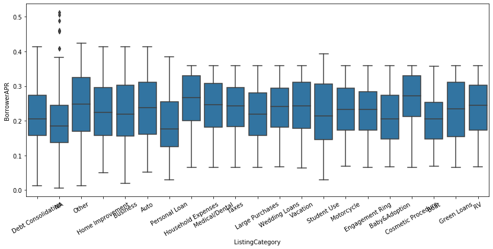

```python
plt.figure(figsize = [14, 6]);
default_color = sns.color_palette()[0]
sns.boxplot(data=df_sub, x='ListingCategory', y='BorrowerAPR', color = default_color, order=sorted_category);
plt.xticks(rotation=30);
```

It is observed that their is no significant relation between any of the Listing Category and Borrower APR as the latter is quite randomly distributed overall across all categories.

Now, as some kind of correlation is present in between each of these quantitative variables, let's explore them one by one.

First, let's look at relationship between `Borrower APR` and `Loan Original Amount`

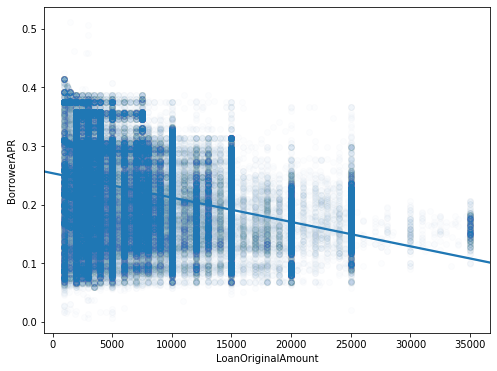

```python
plt.figure(figsize = [8, 6])
sns.regplot(data = df_sub, x = 'LoanOriginalAmount', y = 'BorrowerAPR', scatter_kws={'alpha':0.01});
```

This plot shows that at different size of the loan amount, the APR has a large range, but the range of APR decreases with the increase of loan amount. Overall, the borrower APR is negatively correlated with loan amount.

Finally, let's check at relationship between `Borrower APR` and `StatedMonthlyIncome`

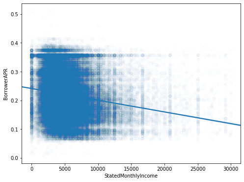

```python
plt.figure(figsize = [8, 6])
sns.regplot(data = df_sub, x = 'StatedMonthlyIncome', y = 'BorrowerAPR', scatter_kws={'alpha':0.01});
```

### Talk about some of the relationships you observed in this part of the investigation. How did the feature(s) of interest vary with other features in the dataset?

The `Borrower APR` is negatively correlated with the `Loan original amount`, which mean the more the loan amount, the lower the APR. It also shows that the range of APR decreases with the increase of loan amount. The `Listing Category` does not seem to have a strong effect on the borrower APR. Other variables such as `DebtToIncomeRatio` and `StatedMonthlyIncome` does not seem to have much impact on `Borrower APR`.

### Did you observe any interesting relationships between the other features (not the main feature(s) of interest)?

Yes, the `Loan original amount` is positively correlated with the `Stated monthly income`, it makes sense since borrowers with more monthly income could loan more money. There is a interaction between prosper rating and term. Proportionally, there are more 60 month loans on B and C ratings. There is only 36 months loans for HR rating borrowers. Also Employed, self-employed and full time borrowers have more monthly income and loan amount than part-time, retired and not employed borrowers.

## Multivariate Exploration

The main thing I want to explore in this part of the analysis is how the categorical variables (`Prosper rating`,`Term` and `Employment Status`) play into the relationship between `Borrower APR`, `Loan original amount` and `Stated Monthly Income`.

So, first let's look at how `Borrower APR`, `Stated Monthly Income` and `Loan original amount` correlate with the categorical variables.

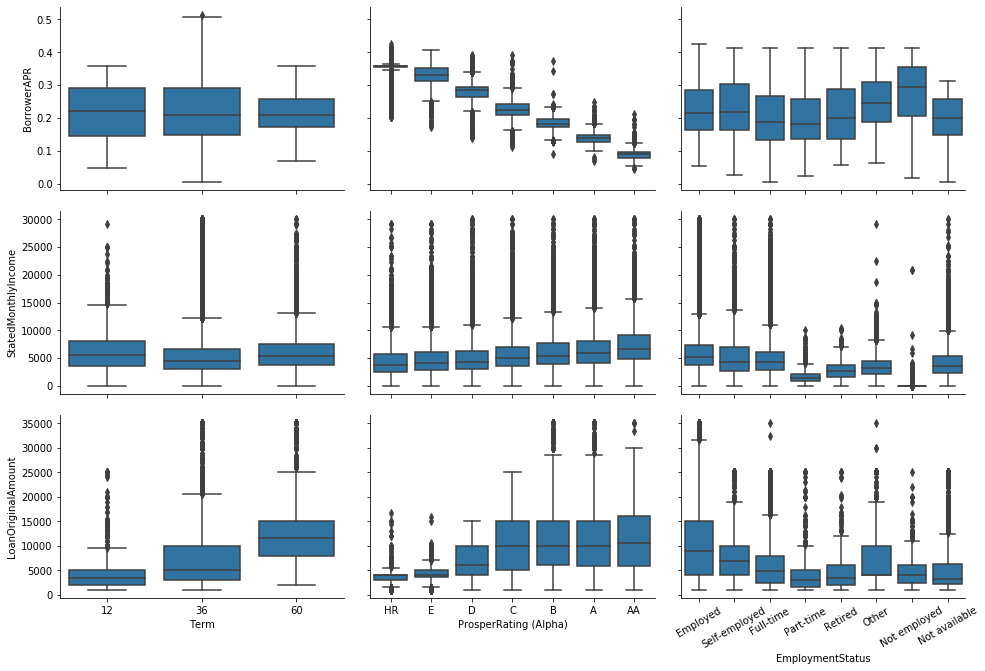

```python
# plot matrix of numeric features against categorical features.

def boxgrid(x, y, **kwargs):
    """ Quick hack for creating box plots with seaborn's PairGrid. """
    default_color = sns.color_palette()[0]
    sns.boxplot(x, y, color = default_color);

plt.figure(figsize = [10, 10]);
g = sns.PairGrid(data = df_sub, y_vars = ['BorrowerAPR', 'StatedMonthlyIncome', 'LoanOriginalAmount'],
                x_vars = cat_vars, height = 3, aspect = 1.5)
g.map(boxgrid);
plt.xticks(rotation=30);
```

Observations:-

- The borrower APR decreases with the better rating. Borrowers with the best Prosper ratings have the lowest APR. It means that the Prosper rating has a strong effect on borrower APR.
- Borrowers with better rating also have both larger monthly income and loan amount.
- The figure shows that the loan amount is increased with the increase of loan term and it is obvious that best Prosper ratings are offered highr loan amounts.
- Employed, self-employed and full time borrowers have more monthly income and loan amount than part-time, retired and not employed borrowers.

Since we observed above that both the variables `Employment Status` and `Stated Monthly Income` do not play a significant role in determining the `Borrower APR`, from now let's just focus on the other variables and exclude these from our analysis.

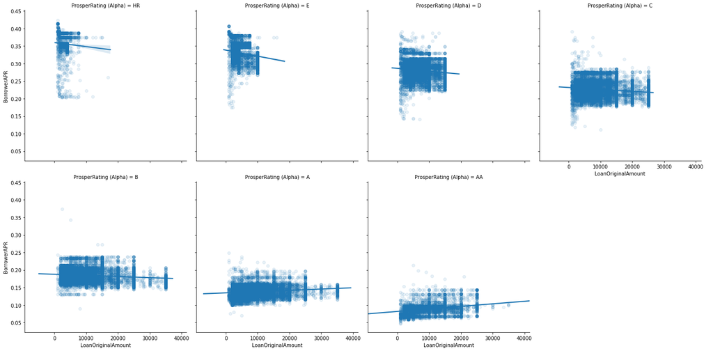

```python
# Prosper rating effect on relationship of APR and loan amount
g=sns.FacetGrid(data=df_sub, height=5, col='ProsperRating (Alpha)', col_wrap=4)
g.map(sns.regplot, 'LoanOriginalAmount', 'BorrowerAPR', x_jitter=0.04, scatter_kws={'alpha':0.1});
g.add_legend();
```

Observations:-

- The loan amount increases with better rating whereas the Borrower APR decreases with better rating.
- The relationship between borrower APR and loan amount turns from negative to slightly positive when the Prosper ratings are increased from HR to AA. This may be because people with A or AA ratings tend to borrow more money, increasing APR could prevent them from borrowing even more and maximize the profit. But people with lower ratings tend to borrow less money, hence decreasing APR for higher loan amounts for them could encourage them to borrow more.

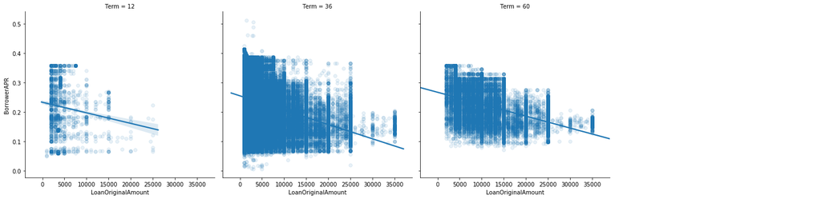

```python
# Term effect on relationship of APR and loan amount
g=sns.FacetGrid(data=df_sub, height=5, col='Term', col_wrap=4)
g.map(sns.regplot, 'LoanOriginalAmount', 'BorrowerAPR', x_jitter=0.04, scatter_kws={'alpha':0.1});
g.add_legend();
```

`Term` doesn't seem to have any noticable effect on relationship of Borrower APR and loan amount because for all terms there is the same negative correlation between Borrower APR and Loan original Amount.

Now let's look at the `Prosper rating` and `Term` effects on `Borrower APR` and `Loan original amount` variables

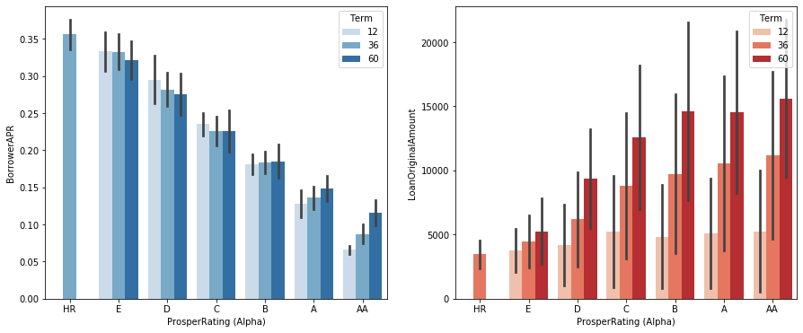

```python
fig, ax = plt.subplots(ncols=2, figsize=[15,6])
sns.barplot(data = df_sub, x = 'ProsperRating (Alpha)', y = 'BorrowerAPR', hue = 'Term',
            palette = 'Blues', dodge = 0.4, ci='sd', ax=ax[0]);
sns.barplot(data = df_sub, x = 'ProsperRating (Alpha)', y = 'LoanOriginalAmount', hue = 'Term',
            palette = 'Reds', dodge = 0.4, ci='sd', ax=ax[1]);
```

Observation:-

- The `Borrower APR` decreases with the increase of borrow `term` for people with HR-C ratings. But for people with B-AA ratings, the APR increase with the increase of borrow term.
- We can also see that with better `Prosper rating`, the `loan amount` of all three `terms` increases, the variability of loan amount between terms also becomes higher.

### Talk about some of the relationships you observed in this part of the investigation. Were there features that strengthened each other in terms of looking at your feature(s) of interest?

I extended my investigation of `Borrower APR` against all quantitative variables by looking at the impact of the other categorical variables. The multivariate exploration showed that `Borrower APR` decreases with the better `Prosper rating`. It means that the Prosper rating has a strong effect on borrower APR. Also, the borrowers with better `Prosper rating` have larger monthly income and loan amount. It was also observed that as the `term` value increases the `loan amount` also increases. The relationship between `Borrower APR` and `Loan amount` turns from negative to slightly positive when the Prosper ratings increased from HR to AA.

I then explored the `Prosper rating` and `Term` effects on `borrower APR` and `loan amount`. It shows that `Borrower APR` decreases with the increase of borrow `Term` for people with HR-C ratings. But for people with B-AA ratings, the APR increases with the increase of borrow term. Also, the `Loan amount` increases as the `Term` period increases and the variability of loan amount between terms also becomes larger.

### Were there any interesting or surprising interactions between features?

An interesting interaction is that the `Borrower APR` and `Loan amount` is negatively correlated when the Prosper ratings are HR, E, D, C and B but the correlation is turned to be positive when the ratings are A and AA. Another interesting thing is that the `Borrower APR` decreases with the increase in borrow `term` for people with HR-C raings. But for people with B-AA ratings, the APR increases with the borrow term.